# SBA at InfMon2 — cord-blood predictor & upstream subclass ratios

Focused re-run: Result #1 (cord WT_IgG -> SBA, with mediation) + Result #2 (absolute subclass ratios at every upstream stage -> SBA)

2026-07-06

# 1 Overview

This report re-runs **two** specific analyses for the **SBA** endpoint (serum bactericidal activity), and nothing else.

Outcome column: `WHOLE_SBA_InfMon2`. Cord predictor: `WHOLE_WT_IgG_CordBlood` | Block-1 maternal signal: `WHOLE_WT_IgG_MatBirth`. Ratio stages: PregEarly, MatBirth, CordBlood.

# 2 Result #1 — Cord-blood predictor (with mediation)

# 3 Cord-blood Whole-cell binding IgG → infant SBA at InfMon2

This part tests whether the **cord-blood level of Whole-cell binding IgG** (WHOLE_WT_IgG_CordBlood) predicts the infant **SBA** at InfMon2 (WHOLE_SBA_InfMon2), over and above the maternal vaccine arm. Because cord blood is measured *before* the infant outcome, this is a genuine temporal predictor rather than a concurrent correlation.

It then asks the mechanistic follow-up: the same measurand at delivery — maternal Whole-cell binding IgG at MatBirth (WHOLE_WT_IgG_MatBirth) — is the **Block-1 maternal chain signal**. Does the cord level *mediate* that maternal signal (maternal delivery antibody → cord antibody → infant function), and does cord retain independent predictive value once the maternal signal is included?

> **Missing expected columns after pivot:** WHOLE_WT_IgG_MatBirth. Check `outcome_feature`, `cord_predictor`, and the visit codes in `config/endpoints.R`.

Wide predictor frame: **240 subjects**. Non-missing: `WHOLE_SBA_InfMon2` = 222, `WHOLE_WT_IgG_CordBlood` = 209, `WHOLE_WT_IgG_MatBirth` = 0.

## 3.1 1 · Adjusted association: cord Whole-cell binding IgG → SBA

Linear model of infant SBA on the cord level plus maternal arm, and the arm-adjusted partial Spearman correlation.

**n = 193 | R² = 0.701 | adj-R² = 0.698 | p<sub>model</sub> = 1.43e-50**

Coefficients — Cord Whole-cell binding IgG + maternal arm

| Predictor | β | SE | t | p |  |
| --- | --- | --- | --- | --- | --- |
| (Intercept) | 0.9149 | 0.0727 | 12.5863 | 0.0000 | *** |
| WHOLE_WT_IgG_CordBlood | 0.8257 | 0.0558 | 14.8071 | 0.0000 | *** |
| arm_nameTT | -0.1498 | 0.0848 | -1.7664 | 0.0789 | ns |

**Partial Spearman** (cord vs SBA, adjusting for maternal arm): rho = 0.628, p = 1.921e-22, n = 193.

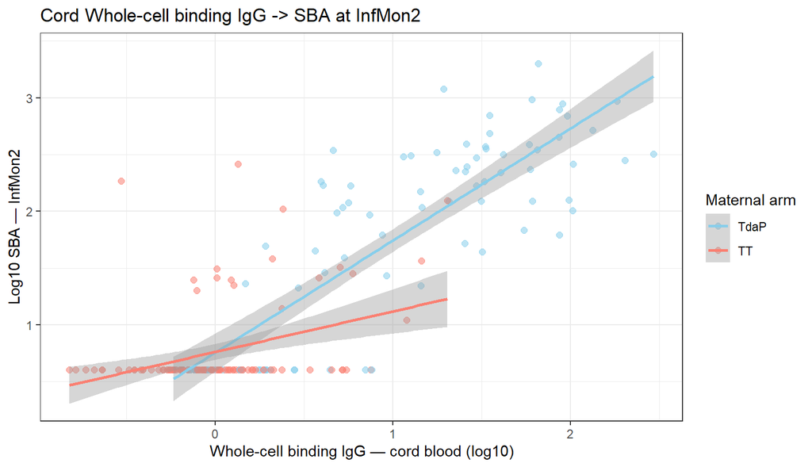

Cord-blood Whole-cell binding IgG vs infant SBA at InfMon2; linear smoother per maternal arm.

## 3.2 2 · Mediation of the Block-1 maternal signal

All three models below are fitted on the **same complete-case sample** (subjects with non-missing outcome, cord and maternal-delivery values) so their coefficients are directly comparable. The question is whether the maternal-delivery coefficient (Block-1 signal) shrinks once the cord level is included — the signature of mediation through cord.

> Maternal Block-1 signal column `WHOLE_WT_IgG_MatBirth` is unavailable, so the mediation comparison is skipped. The adjusted association above still stands.

## 3.3 3 · Interpretation aid

> **🧭 Maps to interpretation:** Reading this block: a significant cord coefficient in §1 establishes that cord Whole-cell binding IgG predicts infant SBA independent of arm. In §2, if the maternal MatBirth (Block-1) coefficient attenuates towards zero once cord is added while cord stays significant, the maternal supply acts on infant function *through* the cord level (transfer as the intermediate); a large proportion mediated is the same message on the effect-decomposition scale.
> - Result #1 of the cord-predictor request

# 4 Result #2 — Absolute subclass ratios at every upstream stage

# 5 Absolute subclass ratios (all upstream stages) → SBA at InfMon2

Pro-inflammatory subclasses: IgG1, IgG3. Tolerogenic: IgG2, IgG4. Ratio = log10[(IgG1 + IgG3) / (IgG2 + IgG4)]; positive = pro-inflammatory polarisation. This part regresses the **absolute** PT / FHA / PRN ratios measured at **PregEarly, MatBirth, CordBlood** on the infant **SBA** at InfMon2, adjusting for maternal arm — first one ratio at a time (consolidated table + forest plot), then all three antigen ratios per stage, then every stage together.

Wide chain frame: **312 subjects**; outcome `WHOLE_SBA_InfMon2` non-missing = 222.  
Absolute-ratio predictors available: **9 of 9** (antigen × stage).

## 5.1 1 · Consolidated univariate table (one ratio at a time, arm-adjusted)

Each row is a single model WHOLE_SBA_InfMon2 ~ ratio + maternal arm. The coefficient (beta) is the slope on that ratio; a positive value means a more pro-inflammatory profile at that stage predicts higher infant SBA.

Absolute pro-/tolerogenic ratio at each stage vs SBA at InfMon2 (each row: outcome ~ ratio + maternal arm; pooled arms).

| Antigen | Stage | n | beta | 95% CI | p | sig |
| --- | --- | --- | --- | --- | --- | --- |
| FHA | PregEarly | 158 | 0.080 | [-0.006, 0.167] | 0.069100 | ns |
| PRN | PregEarly | 158 | 0.559 | [0.261, 0.857] | 0.000297 | *** |
| PT | PregEarly | 158 | 0.419 | [0.088, 0.750] | 0.013400 | * |
| FHA | MatBirth | 151 | -0.010 | [-0.083, 0.063] | 0.786000 | ns |
| PRN | MatBirth | 151 | 0.634 | [0.419, 0.848] | 0.000000 | *** |
| PT | MatBirth | 151 | 0.415 | [0.128, 0.702] | 0.004910 | ** |
| FHA | CordBlood | 144 | -0.015 | [-0.094, 0.064] | 0.704000 | ns |
| PRN | CordBlood | 144 | 0.761 | [0.546, 0.977] | 0.000000 | *** |
| PT | CordBlood | 144 | 0.465 | [0.164, 0.766] | 0.002700 | ** |

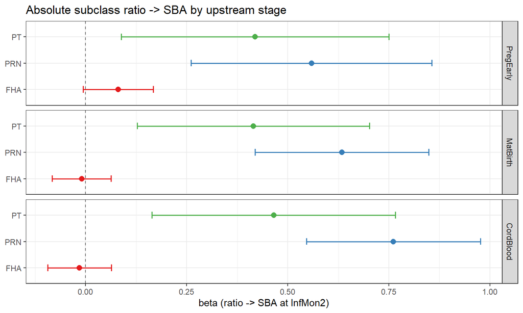

Univariate arm-adjusted slope of each absolute subclass ratio on SBA at InfMon2 (beta with 95% CI), by stage and antigen.

## 5.2 2 · Per-stage multivariable models (three antigen ratios together, arm-adjusted)

### 5.2.1 PregEarly

**n = 158 | R² = 0.428 | adj-R² = 0.413 | p<sub>model</sub> = 9.21e-18**

Coefficients — Ratios @ PregEarly (PT+FHA+PRN) + arm

| Predictor | β | SE | t | p |  |
| --- | --- | --- | --- | --- | --- |
| (Intercept) | 1.3650 | 0.1388 | 9.8348 | 0.00000 | *** |
| PT_ratio_PregEarly | 0.2984 | 0.1701 | 1.7545 | 0.08140 | ns |
| FHA_ratio_PregEarly | 0.0314 | 0.0445 | 0.7065 | 0.48100 | ns |
| PRN_ratio_PregEarly | 0.4911 | 0.1538 | 3.1931 | 0.00171 | ** |
| arm_nameTT | -1.0104 | 0.1015 | -9.9565 | 0.00000 | *** |

### 5.2.2 MatBirth

**n = 151 | R² = 0.467 | adj-R² = 0.453 | p<sub>model</sub> = 3.91e-19**

Coefficients — Ratios @ MatBirth (PT+FHA+PRN) + arm

| Predictor | β | SE | t | p |  |
| --- | --- | --- | --- | --- | --- |
| (Intercept) | 1.0608 | 0.1639 | 6.4710 | 0.00e+00 | *** |
| PT_ratio_MatBirth | 0.1950 | 0.1475 | 1.3218 | 1.88e-01 | ns |
| FHA_ratio_MatBirth | -0.0447 | 0.0343 | -1.3042 | 1.94e-01 | ns |
| PRN_ratio_MatBirth | 0.5954 | 0.1162 | 5.1239 | 9.00e-07 | *** |
| arm_nameTT | -0.6663 | 0.1173 | -5.6829 | 1.00e-07 | *** |

### 5.2.3 CordBlood

**n = 144 | R² = 0.513 | adj-R² = 0.499 | p<sub>model</sub> = 6.82e-21**

Coefficients — Ratios @ CordBlood (PT+FHA+PRN) + arm

| Predictor | β | SE | t | p |  |
| --- | --- | --- | --- | --- | --- |
| (Intercept) | 0.8903 | 0.1804 | 4.9357 | 2.20e-06 | *** |
| PT_ratio_CordBlood | 0.1734 | 0.1446 | 1.1990 | 2.33e-01 | ns |
| FHA_ratio_CordBlood | -0.0523 | 0.0347 | -1.5067 | 1.34e-01 | ns |
| PRN_ratio_CordBlood | 0.7348 | 0.1162 | 6.3224 | 0.00e+00 | *** |
| arm_nameTT | -0.5149 | 0.1296 | -3.9718 | 1.14e-04 | *** |

Per-stage multivariable fit (all three antigen ratios + arm).

| Stage | n | R2 | adj_R2 |
| --- | --- | --- | --- |
| PregEarly | 158 | 0.4281 | 0.4131 |
| MatBirth | 151 | 0.4671 | 0.4525 |
| CordBlood | 144 | 0.5132 | 0.4992 |

## 5.3 3 · All stages together

A single model with every available absolute ratio (antigen x stage) plus maternal arm. Complete-case deletion across all predictors makes this the smallest-n model; the n is reported so the table can be read against the univariate rows above.

**n = 141 | R² = 0.541 | adj-R² = 0.505 | p<sub>model</sub> = 8.32e-18**

Coefficients — All absolute ratios (antigen x stage) + arm

| Predictor | β | SE | t | p |  |
| --- | --- | --- | --- | --- | --- |
| (Intercept) | 0.9017 | 0.1907 | 4.7279 | 5.80e-06 | *** |
| PT_ratio_PregEarly | 0.3613 | 0.2050 | 1.7626 | 8.03e-02 | ns |
| FHA_ratio_PregEarly | 0.0765 | 0.0504 | 1.5182 | 1.31e-01 | ns |
| PRN_ratio_PregEarly | -0.1698 | 0.2194 | -0.7739 | 4.40e-01 | ns |
| PT_ratio_MatBirth | 0.1503 | 0.2166 | 0.6941 | 4.89e-01 | ns |
| FHA_ratio_MatBirth | -0.0427 | 0.0506 | -0.8436 | 4.00e-01 | ns |
| PRN_ratio_MatBirth | -0.0206 | 0.2726 | -0.0755 | 9.40e-01 | ns |
| PT_ratio_CordBlood | -0.1444 | 0.2339 | -0.6176 | 5.38e-01 | ns |
| FHA_ratio_CordBlood | -0.0544 | 0.0546 | -0.9966 | 3.21e-01 | ns |
| PRN_ratio_CordBlood | 0.8471 | 0.2662 | 3.1820 | 1.83e-03 | ** |
| arm_nameTT | -0.6564 | 0.1440 | -4.5601 | 1.17e-05 | *** |

Variance inflation factors (all-stages model).

| term | VIF |
| --- | --- |
| PT_ratio_PregEarly | 1.77 |
| FHA_ratio_PregEarly | 1.44 |
| PRN_ratio_PregEarly | 2.31 |
| PT_ratio_MatBirth | 3.53 |
| FHA_ratio_MatBirth | 2.44 |
| PRN_ratio_MatBirth | 7.71 |
| PT_ratio_CordBlood | 5.04 |
| FHA_ratio_CordBlood | 2.71 |
| PRN_ratio_CordBlood | 7.86 |
| arm_name | 2.18 |

## 5.4 4 · Interpretation aid

> **🧭 Maps to interpretation:** Reading this block: §1 is the requested single consolidated view — every absolute PT/FHA/PRN ratio at PregEarly, MatBirth, CordBlood against infant SBA. §2 asks whether the three antigen ratios at a given stage jointly add signal, and §3 whether ratios across stages carry independent information (watch the n and the VIFs, as the stage ratios are correlated within antigen).
> - Result #2 of the request

# 6 Participant accounting

Every model fitted above, with subjects entered, used after listwise deletion, and the missingness driver behind any drop.

Participant accounting for the cord-predictor and ratio-stage models.

| Section | Stratum | Model | N entered | N used | N dropped | Dropped due to (NA driver) |
| --- | --- | --- | --- | --- | --- | --- |
| Adjusted association | TdaP+TT pooled | Cord Whole-cell binding IgG + maternal arm | 240 | 193 | 47 | WHOLE_WT_IgG_CordBlood (31 NA); WHOLE_SBA_InfMon2 (18 NA) |
| Univariate (arm-adjusted) | TdaP+TT pooled | PT_ratio_PregEarly + arm | 312 | 158 | 154 | WHOLE_SBA_InfMon2 (90 NA); PT_ratio_PregEarly (78 NA) |
| Univariate (arm-adjusted) | TdaP+TT pooled | FHA_ratio_PregEarly + arm | 312 | 158 | 154 | WHOLE_SBA_InfMon2 (90 NA); FHA_ratio_PregEarly (78 NA) |
| Univariate (arm-adjusted) | TdaP+TT pooled | PRN_ratio_PregEarly + arm | 312 | 158 | 154 | WHOLE_SBA_InfMon2 (90 NA); PRN_ratio_PregEarly (78 NA) |
| Univariate (arm-adjusted) | TdaP+TT pooled | PT_ratio_MatBirth + arm | 312 | 151 | 161 | WHOLE_SBA_InfMon2 (90 NA); PT_ratio_MatBirth (83 NA) |
| Univariate (arm-adjusted) | TdaP+TT pooled | FHA_ratio_MatBirth + arm | 312 | 151 | 161 | WHOLE_SBA_InfMon2 (90 NA); FHA_ratio_MatBirth (83 NA) |
| Univariate (arm-adjusted) | TdaP+TT pooled | PRN_ratio_MatBirth + arm | 312 | 151 | 161 | WHOLE_SBA_InfMon2 (90 NA); PRN_ratio_MatBirth (83 NA) |
| Univariate (arm-adjusted) | TdaP+TT pooled | PT_ratio_CordBlood + arm | 312 | 144 | 168 | PT_ratio_CordBlood (93 NA); WHOLE_SBA_InfMon2 (90 NA) |
| Univariate (arm-adjusted) | TdaP+TT pooled | FHA_ratio_CordBlood + arm | 312 | 144 | 168 | FHA_ratio_CordBlood (93 NA); WHOLE_SBA_InfMon2 (90 NA) |
| Univariate (arm-adjusted) | TdaP+TT pooled | PRN_ratio_CordBlood + arm | 312 | 144 | 168 | PRN_ratio_CordBlood (93 NA); WHOLE_SBA_InfMon2 (90 NA) |
| Per-stage multivariable | PregEarly | Ratios @ PregEarly (PT+FHA+PRN) + arm | 312 | 158 | 154 | WHOLE_SBA_InfMon2 (90 NA); PT_ratio_PregEarly (78 NA); FHA_ratio_PregEarly (78 NA); PRN_ratio_PregEarly (78 NA) |
| Per-stage multivariable | MatBirth | Ratios @ MatBirth (PT+FHA+PRN) + arm | 312 | 151 | 161 | WHOLE_SBA_InfMon2 (90 NA); PT_ratio_MatBirth (83 NA); FHA_ratio_MatBirth (83 NA); PRN_ratio_MatBirth (83 NA) |
| Per-stage multivariable | CordBlood | Ratios @ CordBlood (PT+FHA+PRN) + arm | 312 | 144 | 168 | PT_ratio_CordBlood (93 NA); FHA_ratio_CordBlood (93 NA); PRN_ratio_CordBlood (93 NA); WHOLE_SBA_InfMon2 (90 NA) |
| All stages combined | TdaP+TT pooled | All absolute ratios (antigen x stage) + arm | 312 | 141 | 171 | PT_ratio_CordBlood (93 NA); FHA_ratio_CordBlood (93 NA); PRN_ratio_CordBlood (93 NA); WHOLE_SBA_InfMon2 (90 NA); PT_ratio_MatBirth (83 NA); FHA_ratio_MatBirth (83 NA); PRN_ratio_MatBirth (83 NA); PT_r… |